# **Marketing Campaign Analysis**

## **K-Medoids (k=3)**

```python
kmedo = KMedoids(n_clusters=3, random_state=1, method='pam'); preds = kmedo.fit_predict(data_pca)
print(f"Silhouette: {silhouette_score(data_pca, preds):.4f}")
data_pca["KMedoids_3"] = preds; data["KMedoids_3"] = preds; data_model["KMedoids_3"] = preds
print(f"\nDistribution:\n{pd.Series(preds).value_counts().sort_index()}")
```

```
Silhouette: 0.2670

Distribution:
0    950
1    611
2    671
Name: count, dtype: int64
```

### **Visualize clusters using PCA**

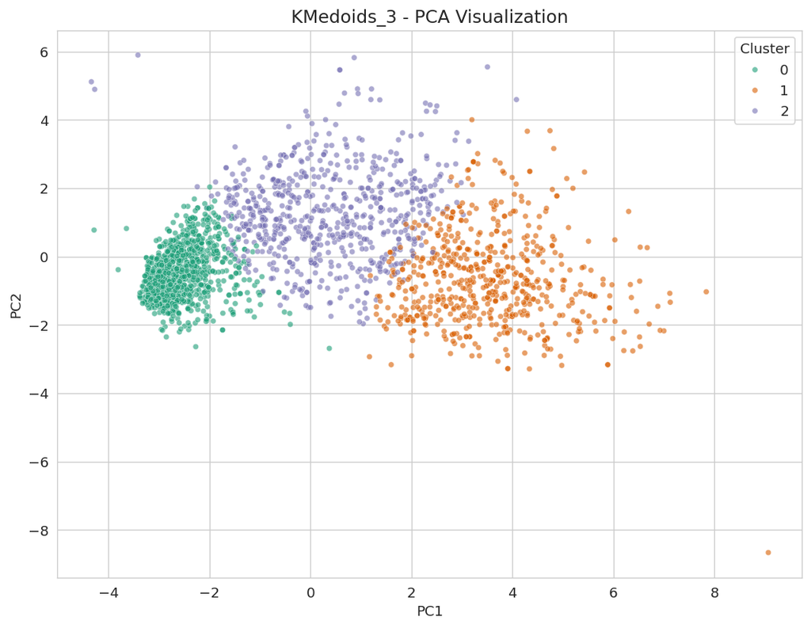

```python
PCA_PLOT(data_pca, "KMedoids_3", "Dark2")
```

### **Cluster Profiling**

```python
cluster_profile = data.groupby('KMedoids_3').mean(numeric_only=True)
cluster_profile.style.highlight_max(color="lightgreen", axis=0).highlight_min(color="lightyellow", axis=0).format("{:.2f}")
```

| KMedoids_3 | Year_Birth | Income | Kidhome | Teenhome | Recency | MntWines | MntFruits | MntMeatProducts | MntFishProducts | MntSweetProducts | MntGoldProds | NumDealsPurchases | NumWebPurchases | NumCatalogPurchases | NumStorePurchases | NumWebVisitsMonth | AcceptedCmp3 | AcceptedCmp4 | AcceptedCmp5 | AcceptedCmp1 | AcceptedCmp2 | Complain | Response | Age | Kids | Status | Family_Size | Expenses | NumTotalPurchases | … |
| --- | --- | --- | --- | --- | --- | --- | --- | --- | --- | --- | --- | --- | --- | --- | --- | --- | --- | --- | --- | --- | --- | --- | --- | --- | --- | --- | --- | --- | --- | --- |
| 0 | 1971.31 | 34441.70 | 0.78 | 0.46 | 49.16 | 32.70 | 4.49 | 19.07 | 6.14 | 4.64 | 13.43 | 1.84 | 1.88 | 0.47 | 3.11 | 6.33 | 0.07 | 0.01 | 0.00 | 0.00 | 0.00 | 0.01 | 0.09 | 44.69 | 1.23 | 1.65 | 2.89 | 80.48 | 7.30 | … |
| 1 | 1968.32 | 75467.28 | 0.05 | 0.25 | 50.34 | 624.50 | 69.28 | 449.56 | 99.03 | 71.74 | 78.19 | 1.52 | 5.47 | 6.00 | 8.48 | 3.07 | 0.08 | 0.13 | 0.24 | 0.20 | 0.03 | 0.01 | 0.28 | 47.68 | 0.30 | 1.62 | 1.92 | 1392.30 | 21.47 | … |
| 2 | 1966.03 | 55166.11 | 0.33 | 0.81 | 47.87 | 398.49 | 18.10 | 120.08 | 26.21 | 18.35 | 56.35 | 3.76 | 5.98 | 2.75 | 7.18 | 5.92 | 0.08 | 0.12 | 0.02 | 0.03 | 0.02 | 0.01 | 0.13 | 49.97 | 1.14 | 1.66 | 2.80 | 637.58 | 19.67 | … |

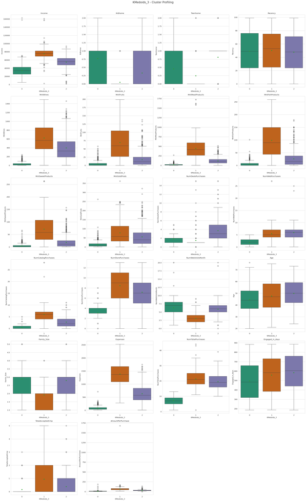

```python
cluster_boxplots(data, "KMedoids_3", "Dark2")
```

**Observations and Insights:**

- K-Medoids produces clusters very similar to K-Means with comparable silhouette scores and distributions.
- This validates that the 3-cluster structure is not an artifact of K-Means' centroid calculation.
- K-Medoids uses actual data points as cluster centers (medoids), making it more robust to outliers by design.
- Computationally slower (PAM has O(n²) complexity) but confirms K-Means results are stable.

**Summary of each cluster:**

- Three clusters mirror K-Means k=3: a high-income premium group, a middle-income mainstream group, and a low-income budget group. Consistency across algorithms strengthens confidence in the segmentation.

```python
# Cleanup
data_pca.drop(columns=['KMedoids_3'], inplace=True, errors='ignore')
data.drop(columns=['KMedoids_3'], inplace=True, errors='ignore')
data_model.drop(columns=['KMedoids_3'], inplace=True, errors='ignore')
```